# Components of a Time Series

←Back to the bookChapter 127 · Components of a Time Series

Chapter 127 · Time Series & Forecasting

Components of a Time Series

Pull six years of monthly sales apart into trend, seasonality, cycle, and irregular noise with statsmodels; then test stationarity with ADF, difference the series to achieve it, and see how autocorrelation separates real signal from white noise.

Statistics, Data Science and AI: A Visual Handbook · John Fisher · 2026

# Components of a Time Series

A **time series** is data indexed by time, one value per period, in order. The order is the whole point: today depends on yesterday. This notebook takes six years of monthly online-store sales and pulls it apart into the four pieces every time series is built from, **trend, seasonality, cycle, and the irregular remainder**, then asks the question every forecasting method starts with: is the series **stationary**? We lean on **statsmodels**, the standard time-series library.

```python
import numpy as np, pandas as pd, matplotlib.pyplot as plt
import seaborn as sns   # seaborn = high-level statistical plots (heatmaps, pairplots, count/bar plots)
from matplotlib.colors import ListedColormap
EM="#0284c7"; DEEP="#075985"; LIGHT="#bae6fd"; INK="#1a2138"; GRID="#e6e9f2"; RED="#ef4444"; AMBER="#d97706"; GREEN="#059669"; BLUE="#2563eb"; PUR="#9333ea"; GREY="#94a3b8"; SLATE="#475569"; ORG="#0284c7"; CYAN="#0891b2"
plt.rcParams.update({"figure.facecolor":"white","axes.facecolor":"white","figure.dpi":110,"font.size":11,
   "axes.edgecolor":GRID,"axes.grid":True,"grid.color":GRID,"axes.axisbelow":True,"axes.spines.top":False,
   "axes.spines.right":False,"axes.titlesize":12,"axes.titleweight":"bold","legend.frameon":False})
sns.set_style("whitegrid")
BASE="https://raw.githubusercontent.com/johnfisher-ai/Statistics-Data-Science-AI-Visual-Book/main/data/"
```

```python
from statsmodels.tsa.seasonal import seasonal_decompose, STL
from statsmodels.tsa.stattools import adfuller, acf
from statsmodels.graphics.tsaplots import plot_acf
import warnings; warnings.filterwarnings('ignore')
```

REAL DATA · A MONTHLY SALES SERIES

Six years of an online store

72 monthly observations, 2018 to 2023.

```python
try: raw = pd.read_excel('../../data/ch127_monthly_retail_sales.xlsx', sheet_name='Data')
except FileNotFoundError: raw = pd.read_excel(BASE + 'ch127_monthly_retail_sales.xlsx', sheet_name='Data')
raw['month'] = pd.to_datetime(raw['month'])
s = raw.set_index('month')['sales'].asfreq('MS')     # a proper monthly time index
print('points:', len(s), '| from', s.index.min().date(), 'to', s.index.max().date())
s.head()
```

```
points: 72 | from 2018-01-01 to 2023-12-01
```

```
month
2018-01-01    14405
2018-02-01    15019
2018-03-01    20594
2018-04-01    20760
2018-05-01    19937
Freq: MS, Name: sales, dtype: int64
```

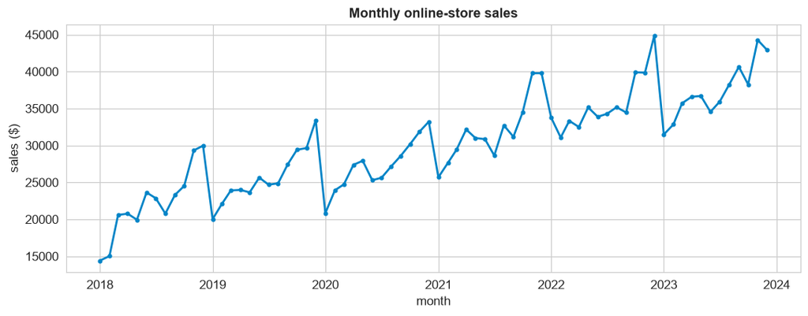

```
first-year avg 22088  ->  last-year avg 37342  (the series is trending up)
```

```python
fig,ax=plt.subplots(figsize=(10,4))
ax.plot(s.index, s.values, color=EM, lw=1.8, marker='o', ms=3)
ax.set(title='Monthly online-store sales', ylabel='sales ($)', xlabel='month')
plt.tight_layout(); plt.show()
print('first-year avg %d  ->  last-year avg %d  (the series is trending up)' % (s[:12].mean(), s[-12:].mean()))
```

Two things jump out of the raw plot: the level **drifts upward** year over year, and a **repeating yearly wave** peaks every December. Those are the first two components. Let us name all four.

DEMO 1 · THE FOUR COMPONENTS

Trend, seasonality, cycle, irregular

Every time series is a sum of these pieces.

- **Trend** the long-run direction (here, steady growth).
- **Seasonality** a pattern that repeats on a fixed calendar period (here, every 12 months).
- **Cyclical** longer swings with no fixed length (business cycles, multi-year booms and busts).
- **Irregular** the random leftover once the rest is removed.

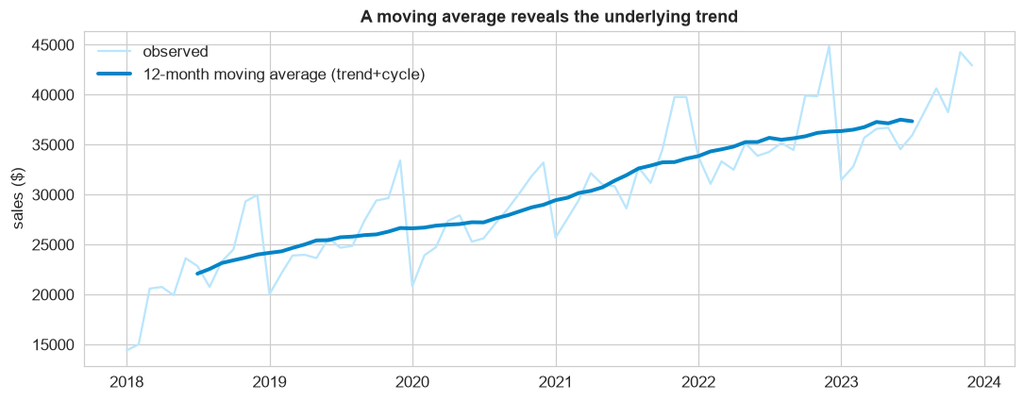

```
a 12-month moving average averages out one full seasonal cycle, leaving trend + slow cycle
```

```python
ma12 = s.rolling(12, center=True).mean()     # a 12-month moving average smooths away the yearly wave
fig,ax=plt.subplots(figsize=(10,4))
ax.plot(s.index, s.values, color=LIGHT, lw=1.5, label='observed')
ax.plot(ma12.index, ma12.values, color=EM, lw=2.6, label='12-month moving average (trend+cycle)')
ax.set(title='A moving average reveals the underlying trend', ylabel='sales ($)'); ax.legend()
plt.tight_layout(); plt.show()
print('a 12-month moving average averages out one full seasonal cycle, leaving trend + slow cycle')
```

A **centered 12-month moving average** cancels the yearly ups and downs (they sum to about zero over a year), leaving the smooth trend-plus-cycle underneath. That is the intuition behind formal decomposition.

DEMO 2 · DECOMPOSITION

Split the series in one line

statsmodels does the arithmetic for you.

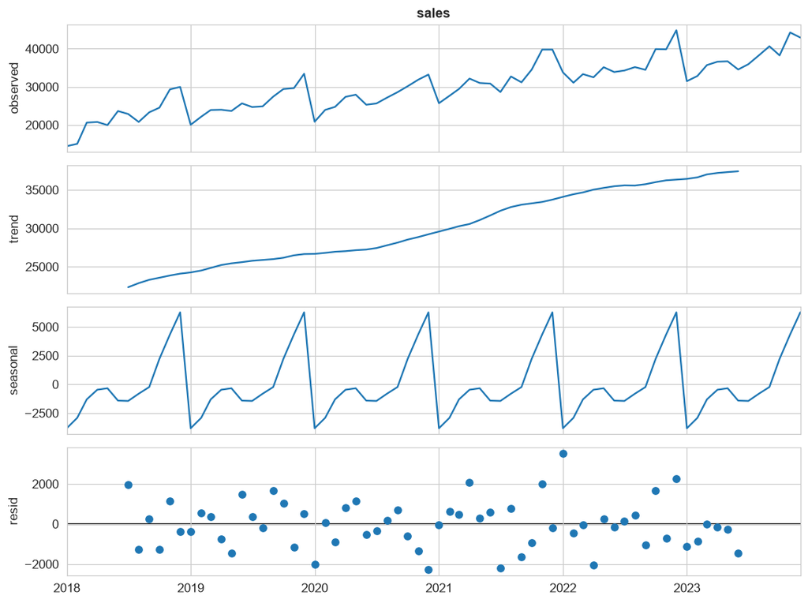

```python
dec = seasonal_decompose(s, model='additive', period=12)
fig = dec.plot(); fig.set_size_inches(10,7.5); [a.set_ylabel(l) for a,l in zip(fig.axes,['observed','trend','seasonal','resid'])]
plt.tight_layout(); plt.show()
```

```python
slope = np.polyfit(np.arange(len(s)), s.values, 1)[0]
seas = dec.seasonal.groupby(dec.seasonal.index.month).mean()
print('trend: about $%d per month (~$%d per year)' % (slope, slope*12))
print('seasonal peak: month %d (+$%d)  |  trough: month %d ($%d)' % (seas.idxmax(), seas.max(), seas.idxmin(), seas.min()))
print('irregular (residual) std: about $%d' % np.nanstd(dec.resid))
```

```
trend: about $283 per month (~$3406 per year)
seasonal peak: month 12 (+$6258)  |  trough: month 1 ($-3825)
irregular (residual) std: about $1184
```

`seasonal_decompose` splits the series into **observed = trend + seasonal + residual**. The readout confirms the eye: the trend adds roughly **284 dollars a month** (about 3,400 a year), the seasonal effect peaks in **December (about +6,300)** and bottoms in **January (about -3,800)**, and the leftover irregular noise has a standard deviation near **1,200 dollars**. The seasonal panel is a clean repeating shape, exactly what “seasonality” means.

DEMO 3 · ADDITIVE OR MULTIPLICATIVE?

Does the swing grow with the level?

Two ways the pieces combine.

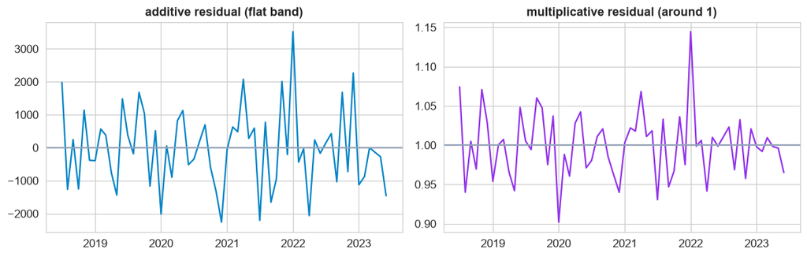

```
additive: observed = trend + seasonal + resid  (seasonal swing is a fixed dollar amount)
multiplicative: observed = trend x seasonal x resid  (swing grows in proportion to the level)
```

```python
mult = seasonal_decompose(s, model='multiplicative', period=12)
fig,ax=plt.subplots(1,2,figsize=(11,3.6))
ax[0].plot(dec.resid.index, dec.resid.values, color=EM); ax[0].axhline(0,color=GREY); ax[0].set(title='additive residual (flat band)')
ax[1].plot(mult.resid.index, mult.resid.values, color=PUR); ax[1].axhline(1,color=GREY); ax[1].set(title='multiplicative residual (around 1)')
plt.tight_layout(); plt.show()
print('additive: observed = trend + seasonal + resid  (seasonal swing is a fixed dollar amount)')
print('multiplicative: observed = trend x seasonal x resid  (swing grows in proportion to the level)')
```

In an **additive** series the seasonal swing is a roughly constant size; in a **multiplicative** one it grows as the series grows (think percentages, not dollars). A quick tell: if the yearly wave gets visibly taller as the trend rises, go multiplicative, or model `log(sales)`, which turns a multiplicative series into an additive one. Here the additive residual sits in a flat band, so additive is a fair fit.

DEMO 4 · IS IT STATIONARY?

The question forecasting starts with

Constant mean and variance, or not?

A series is **stationary** when its statistical behavior does not depend on time: a roughly **constant mean and variance**, and no trend or seasonality. Most models assume it, and most raw series fail it. The **Augmented Dickey-Fuller (ADF)** test checks formally, a small p-value means stationary.

```python
def adf(x, label):
    p = adfuller(x.dropna())[1]
    print(f'{label:26s} ADF p = {p:.3f}  ->  {"stationary" if p<0.05 else "NON-stationary"}')
adf(s, 'raw series')
adf(s.diff(), 'first difference')
```

```
raw series                 ADF p = 0.903  ->  NON-stationary
first difference           ADF p = 0.021  ->  stationary
```

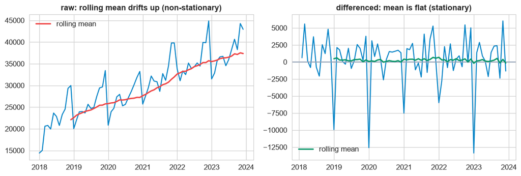

```python
fig,ax=plt.subplots(1,2,figsize=(11,3.8))
ax[0].plot(s.index, s.values, color=EM); ax[0].plot(s.rolling(12).mean().index, s.rolling(12).mean().values, color=RED, lw=2, label='rolling mean')
ax[0].set(title='raw: rolling mean drifts up (non-stationary)'); ax[0].legend()
d1 = s.diff()
ax[1].plot(d1.index, d1.values, color=EM); ax[1].axhline(0,color=GREY); ax[1].plot(d1.rolling(12).mean().index, d1.rolling(12).mean().values, color=GREEN, lw=2, label='rolling mean')
ax[1].set(title='differenced: mean is flat (stationary)'); ax[1].legend()
plt.tight_layout(); plt.show()
```

The raw series fails the test (**p about 0.90**): its rolling mean climbs, so the mean depends on time. **Differencing**, replacing each value with its change from the month before, removes the trend, and the first difference passes (**p about 0.02**). Differencing is the standard move to make a series stationary, and it is exactly the “I” (integrated) in ARIMA, which the next chapter builds on.

DEMO 5 · WHITE NOISE & AUTOCORRELATION

The baseline a good model reduces to

If residuals are white noise, you have captured the signal.

```
white noise: mean 0.02, constant variance, no memory
ACF of raw series  lag-1 = 0.79 (strong memory), lag-12 = 0.58 (seasonal echo)
ACF of white noise lag-1 = 0.04 (no memory)
```

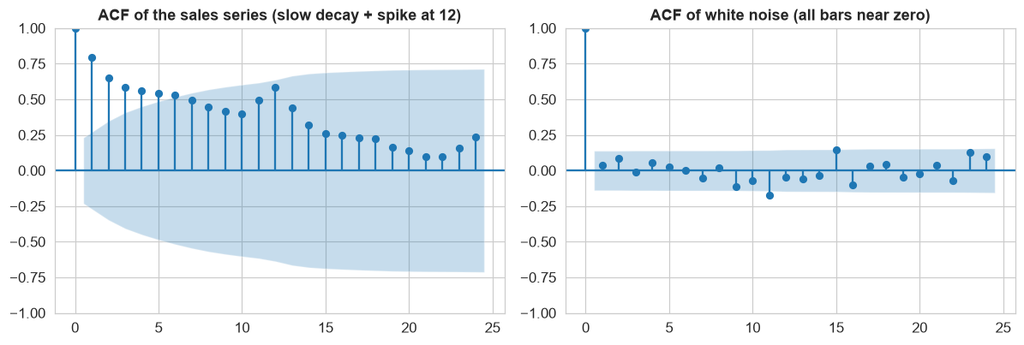

```python
wn = pd.Series(np.random.default_rng(0).normal(0, 1, 200))
print('white noise: mean %.2f, constant variance, no memory' % wn.mean())
print('ACF of raw series  lag-1 = %.2f (strong memory), lag-12 = %.2f (seasonal echo)' % (acf(s.dropna(),nlags=12)[1], acf(s.dropna(),nlags=12)[12]))
print('ACF of white noise lag-1 = %.2f (no memory)' % acf(wn,nlags=1)[1])
fig,ax=plt.subplots(1,2,figsize=(11,3.8))
plot_acf(s.dropna(), lags=24, ax=ax[0]); ax[0].set(title='ACF of the sales series (slow decay + spike at 12)')
plot_acf(wn, lags=24, ax=ax[1]); ax[1].set(title='ACF of white noise (all bars near zero)')
plt.tight_layout(); plt.show()
```

**White noise** is a series with zero mean, constant variance, and **no autocorrelation**, no memory from one step to the next. It is the thing you cannot forecast, and the goal is for your model's **residuals** to look like it. The **autocorrelation function (ACF)** makes memory visible: the sales series correlates strongly with its recent past (lag-1 about 0.79) and shows a **spike at lag 12** (the yearly echo), while white noise has every bar near zero. When residuals finally look like the right-hand plot, the signal has been captured.

## The four components, in one view

1. **Trend** the long-run direction; smooth it out with a moving average.
2. **Seasonality** a fixed-period repeat (here every 12 months, peaking in December).
3. **Cyclical** longer, irregular swings with no fixed length.
4. **Irregular** the random remainder, ideally white noise.

**The one idea to keep: a time series is trend plus season plus cycle plus noise, and the first job is always to check stationarity, because differencing a non-stationary series into a stationary one is the doorway to every forecasting model ahead.**

Statistics, Data Science and AI: A Visual Handbook · © 2026 John Fisher

←Back to the bookChapter 127 · Components of a Time Series